# Experimentação de cigarro por jovens no município do Rio de Janeiro, Análise exploratória

Lucas Dirk Gomes Ferreira

19/07/2021

```r
library(srvyr)
library(survey)
library(survival)
library(tidyverse)
library("gplots")
library(DT)
require(knitr)
```

### A base de dados dessa análise será a amostra 1 da PENSE 2015, essa amostra contempla os escolares frequentando a oitava série do ensino fundamental. Vale ressaltar que a pesquisa utilizada faz a expansão para a população com um intervalo de confiança de 95%

```r
BaseBR2015 = read.csv2(file = 'PENSE.csv',header=T, sep=";")
```

### Aplicando o desenho da amostra da PENSE 2015.

```r
desenho = svydesign(id =~ escola,

  strata =~ ESTRATOGEOREG,
  weights =~ as.numeric(PESO),
  data = BaseBR2015,
  nest = T)
```

### Aplicando o desenho para o município do Rio de Janeiro.Para a criação do desenho do município, foi utilizado o dicionário das variáveis da PENSE 2015.

```r
desenhoRJ = subset(desenho, UFCENSO == 33 & TIPO_MUNIC == 1)
```

# Análise exploratória dos dados

### Conhecendo a faixa etária da nossa população, vale ressaltar que o comando utilizado foi o “svytable(~factor(VB01003),desenhoRJ)” para ser feita a expansão da amostra para população.

```r
# svytable(~factor(VB01003),desenhoRJ)

idade = c ("11 anos ou menos","12 anos","13 anos","14 anos","15 anos","16 anos","17 anos", "18 anos","19 anos ou mais")

valores = c(29.04, 136.99,  5794.07, 40038.003, 19618.33, 4404.52, 660.94, 135.19, 225.60)

porce = 100/sum(valores)
porcentagem = valores*porce
porcentagem = sprintf("%.3f", porcentagem)

tabela0 = data.frame(Idade = idade, Valores = valores, . = paste(porcentagem,'%'))

DT::datatable(tabela0, rownames = FALSE)
```

| Idade | Valores | . |
| --- | --- | --- |
| 11 anos ou menos | 29.04 | 0.041 % |
| 12 anos | 136.99 | 0.193 % |
| 13 anos | 5794.07 | 8.156 % |
| 14 anos | 40038.003 | 56.358 % |
| 15 anos | 19618.33 | 27.615 % |
| 16 anos | 4404.52 | 6.200 % |
| 17 anos | 660.94 | 0.930 % |
| 18 anos | 135.19 | 0.190 % |
| 19 anos ou mais | 225.6 | 0.318 % |

### Distribuição de Frequência sobre o uso de cigarro estimada para população. Os dados foram obtidos através da pergunta: Alguma vez na vida, você já fumou cigarro, mesmo uma ou duas tragadas?. O comando utilizado foi “#svytable(~factor(VB04001),desenhoRJ)”

```r
resposta = c("Sim","Não")

valores = c(11660.90, 59381.82)

porce = 100/sum(valores)
porcentagem = valores*porce
porcentagem = sprintf("%.2f", porcentagem)

tabela1 = data.frame(Resposta = resposta, Valores = valores, . = paste(porcentagem,'%'))
DT::datatable(tabela1, rownames = FALSE)
```

| Resposta | Valores | . |
| --- | --- | --- |
| Sim | 11660.9 | 16.41 % |
| Não | 59381.82 | 83.59 % |

### Gráfico de barras para representar a quantidade de jovens que já utilizaram cigarro e jovens que não.

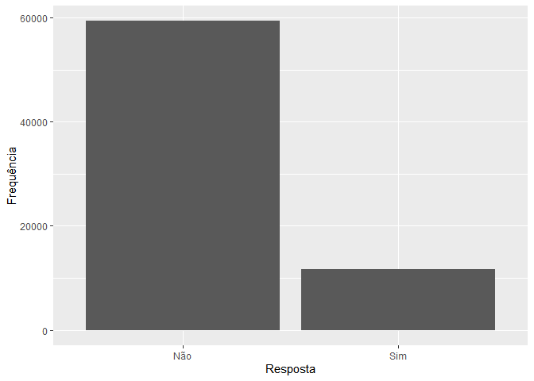

```r
demo <- tribble(
  ~Resposta, ~Frequência,
  "Sim", 11660.90,
  "Não", 59381.82
)

ggplot( data = demo) +
  geom_bar(
    mapping = aes( x = Resposta, y = Frequência ), stat = "identity"
  )
```

### Distribuição de Frequência sobre uso de cigarro em relação a idade estimada para população. Dados obtidos através da pergunta: Que idade você tinha quando experimentou fumar cigarro pela primeira vez?. Comando utilizado “svytable(~factor(VB04002),desenhoRJ)”

```r
resposta = c( "7 anos ou menos","8 anos", "9 anos","10 anos", "11 anos","12 anos","13 anos","14 anos","15 anos", "16 anos","Não informado")

valores = c( 429.05, 340.55, 130.70, 411.27, 237.85, 1501.98, 2837.03, 4323.47,  1025.51,   392.74, 30.70)

porce = 100/sum(valores)
porcentagem = valores*porce
porcentagem = sprintf("%.2f", porcentagem)

tabela2 = data.frame(Resposta = resposta, Valores = valores, . =paste (porcentagem,'%'))
DT::datatable(tabela2, rownames = FALSE)
```

| Resposta | Valores | . |
| --- | --- | --- |
| 7 anos ou menos | 429.05 | 3.68 % |
| 8 anos | 340.55 | 2.92 % |
| 9 anos | 130.7 | 1.12 % |
| 10 anos | 411.27 | 3.53 % |
| 11 anos | 237.85 | 2.04 % |
| 12 anos | 1501.98 | 12.88 % |
| 13 anos | 2837.03 | 24.33 % |
| 14 anos | 4323.47 | 37.08 % |
| 15 anos | 1025.51 | 8.79 % |
| 16 anos | 392.74 | 3.37 % |

[output cut: 1 more lines]

### Gráfico de barras para representar a idade em que cada jovem experimentou cigarro pela primeira vez.

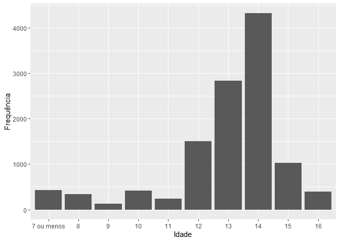

```r
demo <- tribble(
    ~Idade, ~Frequência,
    "7 ou menos", 429.05,
    "8", 340.55,
    "9", 130.70,
     "10", 411.27,
    "11", 237.85,
    "12", 1501.98,
    "13", 2837.03,
    "14", 4323.47,
    "15",1025.51,
    "16",392.74



  )
 demo$Idade = factor(demo$Idade, levels = c( "7 ou menos", "8", "9" , "10", "11" , "12" , "13" , "14" , "15" , "16"))

  ggplot( data = demo) +
    geom_bar( mapping = aes( x = Idade, y = Frequência), stat = "identity"
    )
```

### Agora iremos investigar algumas variáveis com possível associação a experimentação do cigarro. As variáveis investigadas serão: Sexo, Raça e idade e dependência administrativa da escola. Vale ressaltar que não será realizada a expansão para fazermos uma análise exploratória em cima da amostra do município do Rio de Janeiro.

### Tabela de contingência entre as variáveis “Já fumou?” e “Sexo”.

```r
amostra = BaseBR2015 %>% filter (MUNICIPIO_CAP == 3304557)

contigencia_cigarro_sexo = table(amostra$VB04001, amostra$VB01001)

colnames(contigencia_cigarro_sexo) = c("Masculino", "Feminino")
rownames(contigencia_cigarro_sexo) = c("Ja fumou", "Não Fumou")
contigencia_cigarro_sexo
```

```
##
##             Masculino Feminino
##   Ja fumou        141      214
##   Não Fumou       854      910
```

### Agora será plotado três gráficos para facilitar a visualização da relação entre as variáveis “Já fumou?” e “Sexo”.

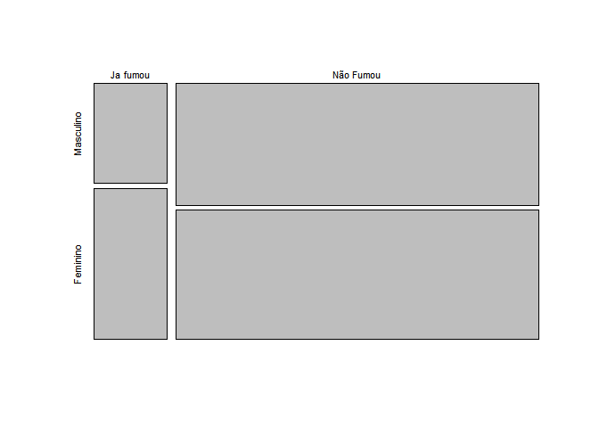

```r
plot(contigencia_cigarro_sexo, main ='')
```

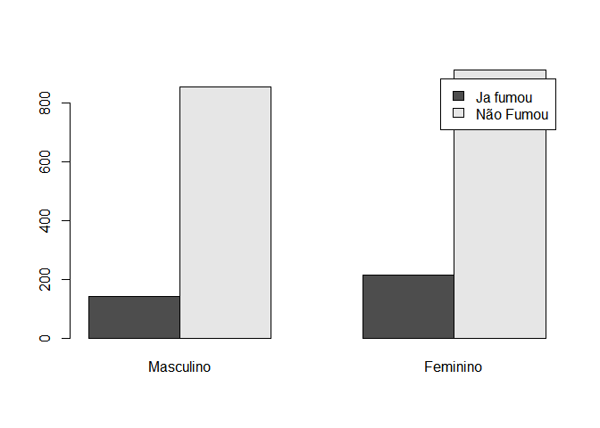

```r
barplot(contigencia_cigarro_sexo, beside = T, legend = T)
```

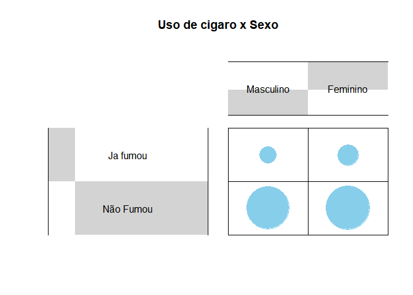

```r
dt <- as.table(as.matrix(contigencia_cigarro_sexo))
balloonplot(t(dt), main ="Uso de cigaro x Sexo", xlab ="", ylab="",
            label = FALSE, show.margins = FALSE)
```

### Usando o teste qui-quadrado de Pearson, sendo h0: Não há associação entre as variáveis sexo e experimentação do cigarro. Serão aceitos como estatisticamente significativos p valores menores que 0,05. Logo, como p < 0.05, se rejeita h0.

```r
chisq = chisq.test(contigencia_cigarro_sexo)
chisq
```

```
##
##  Pearson's Chi-squared test with Yates' continuity correction
##
## data:  contigencia_cigarro_sexo
## X-squared = 8.6234, df = 1, p-value = 0.003319
```

### Na variável raça, será categorizado as cores pretas e pardas, formando a raça negra. Também será colocado como “outras” amarelos e indígenas devido sua pouca representatividade na amostra.

```r
raca = c()
for (x in 1:length(BaseBR2015$VB01002)){

  # Nova regra, 1 branca
  if (BaseBR2015$VB01002[x] == 1){
    raca = append(raca,1)

  }

  # Nova regra, 2 Negra
  else if (BaseBR2015$VB01002[x] == 2 || BaseBR2015$VB01002[x] == 4 ){
    raca = append(raca,2)

  }


  # Nova regra, 3 outras

  else if (BaseBR2015$VB01002[x] == 3  || BaseBR2015$VB01002[x] == 5 ){
    raca = append(raca,3)

  }

  #Nova regra, 99 Não informado
  else {
    raca = append(raca, 99)

  }
}
```

### Adicionando a variável raça na base.

```r
BaseBR2015 = transform(BaseBR2015, raca = raca)

desenho = svydesign(id =~ escola,

  strata =~ ESTRATOGEOREG,
  weights =~ as.numeric(PESO),
  data = BaseBR2015,
  nest = T)

desenhoRJ = subset(desenho, UFCENSO == 33 & TIPO_MUNIC == 1)
```

### Tabela de contingência entre as variáveis “Ja fumou?” e “Raça”.

```r
amostra = BaseBR2015 %>% filter (MUNICIPIO_CAP == 3304557)


contigencia_cigarro_raca = table(amostra$VB04001, amostra$raca)

colnames(contigencia_cigarro_raca) =  c("Branca", "Negra","Outras","Não informado")
rownames(contigencia_cigarro_raca) = c("Já fumou","Não Fumou")

contigencia_cigarro_raca
```

```
##
##             Branca Negra Outras Não informado
##   Já fumou     139   184     32             0
##   Não Fumou    784   844    135             1
```

### Agora será plotado dois gráficos para facilitar a visualização da relação entre as variáveis “Já fumou?” e “Raça”

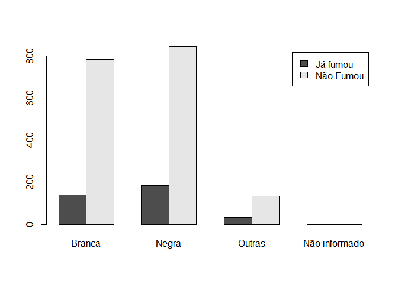

```r
barplot(contigencia_cigarro_raca, beside = T, legend = T)
```

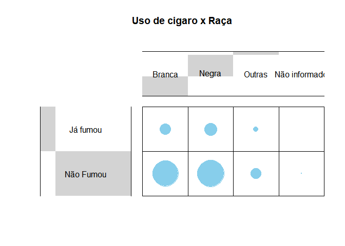

```r
dt <- as.table(as.matrix(contigencia_cigarro_raca))
balloonplot(t(dt), main ="Uso de cigaro x Raça", xlab ="", ylab="",
            label = FALSE, show.margins = FALSE)
```

### Usando o teste qui-quadrado de Pearson, sendo h0: Não há associação entre as variáveis raça e experimentação do cigarro. Serão aceitos como estatisticamente significativos p valores menores que 0,05. Como o p-valor > 0.05, h0 não será rejeitado.

```r
chisq = chisq.test(contigencia_cigarro_raca)
chisq
```

```
##
##  Pearson's Chi-squared test
##
## data:  contigencia_cigarro_raca
## X-squared = 3.7616, df = 3, p-value = 0.2884
```

### Tabela de contingência entre as variáveis “Já fumou?” e “Idade”.

```r
amostra = BaseBR2015 %>% filter (MUNICIPIO_CAP == 3304557)


contigencia_cigarro_idade = table(amostra$VB04001, amostra$VB01003)
rownames(contigencia_cigarro_idade) = c("Já fumou","Não Fumou")
colnames(contigencia_cigarro_idade) =  c("11 -", "12","13","14" ,"15","16","17" ,"18","19 +")

contigencia_cigarro_idade
```

```
##
##             11 -   12   13   14   15   16   17   18 19 +
##   Já fumou     0    2   17  147  128   53    7    1    0
##   Não Fumou    1    2  159 1044  454   80   14    3    7
```

### Agora será plotado dois gráficos para facilitar a visualização da relação entre as variáveis “Já fumou?” e “idade”

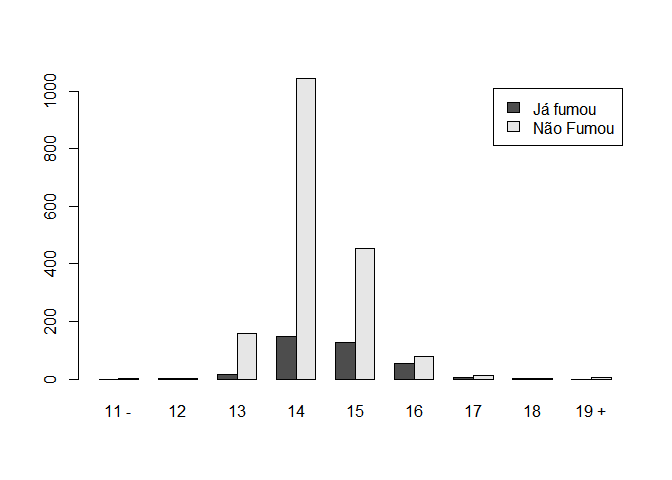

```r
barplot(contigencia_cigarro_idade, beside = T, legend = T)
```

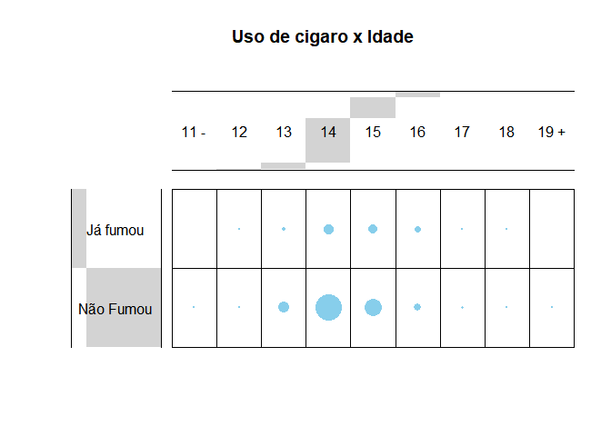

```r
dt <- as.table(as.matrix(contigencia_cigarro_idade))
balloonplot(t(dt), main ="Uso de cigaro x Idade", xlab ="", ylab="",
            label = FALSE, show.margins = FALSE)
```

### Tabela de contingência entre as variáveis “Já fumou?” e “Dependência administrativa da escola”.

```r
amostra = BaseBR2015 %>% filter (MUNICIPIO_CAP == 3304557)


contigencia_cigarro_escola = table(amostra$VB04001, amostra$V0007)

rownames(contigencia_cigarro_escola) = c("Já fumou","Não Fumou")
colnames(contigencia_cigarro_escola) = c("Publica","Privada")

contigencia_cigarro_escola
```

```
##
##             Publica Privada
##   Já fumou      248     107
##   Não Fumou    1037     727
```

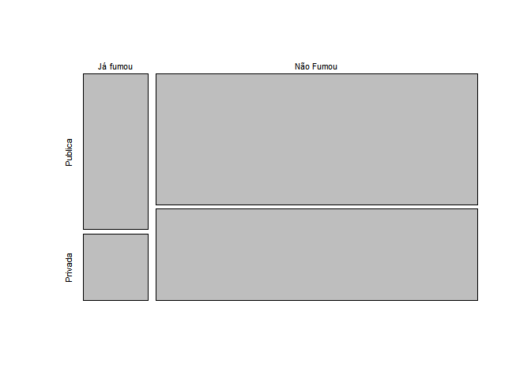

```r
plot(contigencia_cigarro_escola, main ='')
```

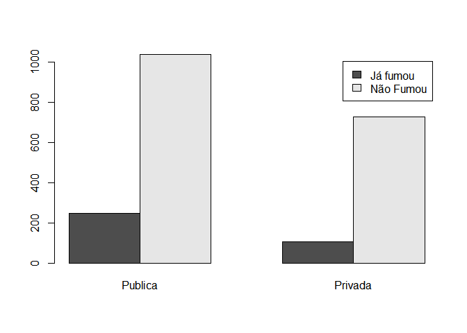

```r
barplot(contigencia_cigarro_escola, beside = T, legend = T)
```

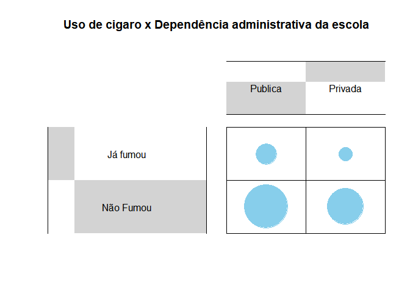

```r
dt <- as.table(as.matrix(contigencia_cigarro_escola))
balloonplot(t(dt), main ="Uso de cigaro x Dependência administrativa da escola", xlab ="", ylab="",
            label = FALSE, show.margins = FALSE)
```

```r
chisq = chisq.test(contigencia_cigarro_escola)
chisq
```

```
##
##  Pearson's Chi-squared test with Yates' continuity correction
##
## data:  contigencia_cigarro_escola
## X-squared = 14.719, df = 1, p-value = 0.0001248
```

# Análise de sobrevivência

### Tendo em vista que muitos dados são censurados, ou seja, muitos jovens ainda não experimentaram cigarro pela primeira vez, vale a pena fazer uma análise de sobrevivência para esses dados serem considerados e analisados através da função de sobrevivência, tal função representa a probabilidade do jovem não ter experimentado o fenômeno até um certo tempo t. Vale ressaltar que os dados foram estimados para toda população.

### Criação da variável “Tempo” e “Censura” para o consumo de cigarro. 0 significa censura a direita, 1 significa falha.

```r
censura = c()
tempo = c()

for (i in 1:length(BaseBR2015$VB04002)){

  if (BaseBR2015$VB04002[i] == -1){

    tempo = append(tempo, BaseBR2015$VB01003[i])
    censura = append(censura, 0)
  }

  else if (BaseBR2015$VB04002[i]>=7 && BaseBR2015$VB04002[i]<=18){

    tempo = append(tempo,BaseBR2015$VB04002[i])
    censura = append(censura, 1)

  }

  else if (BaseBR2015$VB04002[i] == 99 || BaseBR2015$VB04001[i] == 99){
    tempo = append(tempo, NA)
    censura = append(censura, NA)

  }

}
```

### Adicionando as variáveis tempo e censura na base.

```r
BaseBR2015 = transform(BaseBR2015, tempo=tempo, censura=censura)

desenho = svydesign(id =~ escola,

  strata =~ ESTRATOGEOREG,
  weights =~ as.numeric(PESO),
  data = BaseBR2015,
  nest = T)

desenhoRJ = subset(desenho, UFCENSO == 33 & TIPO_MUNIC == 1)
```

### Estimação da função de sobrevivência da iniciação ao cigarro pelo estimador de Kaplan-Meier.

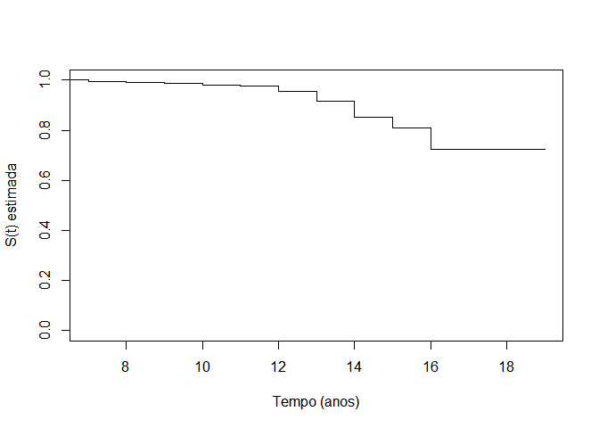

```r
ekm = svykm(Surv(tempo,censura)~1,design = desenhoRJ)
plot(ekm,  xlab="Tempo (anos)",xlim = c(7,19), ylab="S(t) estimada")
```

### Estimação da função de sobrevivência da iniciação ao cigarro pelo estimador de Kaplan-Meier, usando como variavél explicativa o sexo

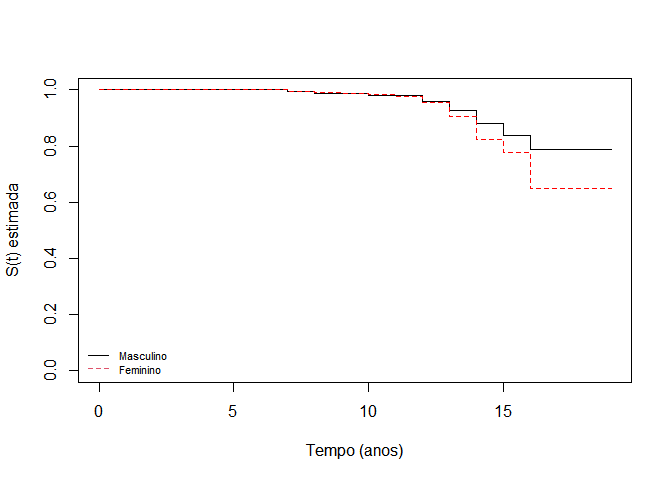

```r
ekm.sexo = svykm(Surv(tempo,censura)~VB01001,design=desenhoRJ)
plot(ekm.sexo,xlab = "Tempo (anos)",ylab = "S(t) estimada",pars=list(lty=c(1,2),col=c("black","red")))
Legenda<-c("Masculino","Feminino")
legend("bottomleft", Legenda,lwd=c(1,1),cex=0.7,inset=0.00,col=c(1,2),bty="n", lty = c(1,2))
```

### Estimação da função de sobrevivência, usando como variável explicativa a dependência administrativa da escola.

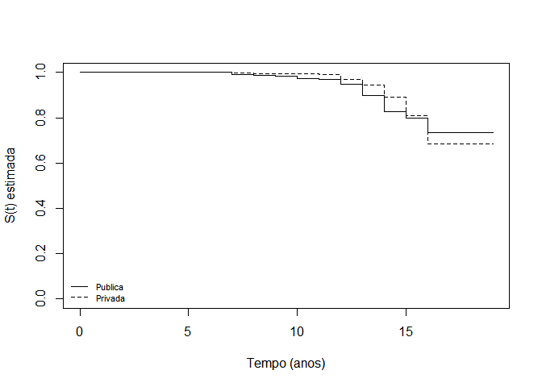

```r
ekm.depAdm = svykm(Surv(tempo,censura)~V0007,design=desenhoRJ)
plot(ekm.depAdm,ylab = "S(t) estimada",xlab = "Tempo (anos)"
     ,pars=list(lty=c(1,2),col=c("black","black")))
Legenda<-c("Publica","Privada")
legend("bottomleft", Legenda,lwd=c(1,1),cex=0.7,inset=0.00,col=c(1,1),bty="n", lty = c(1,2))
```

### Estimação da função de sobrevivência da iniciação ao cigarro pelo estimador de Kaplan-Meier, usando como variável explicativa a raça.

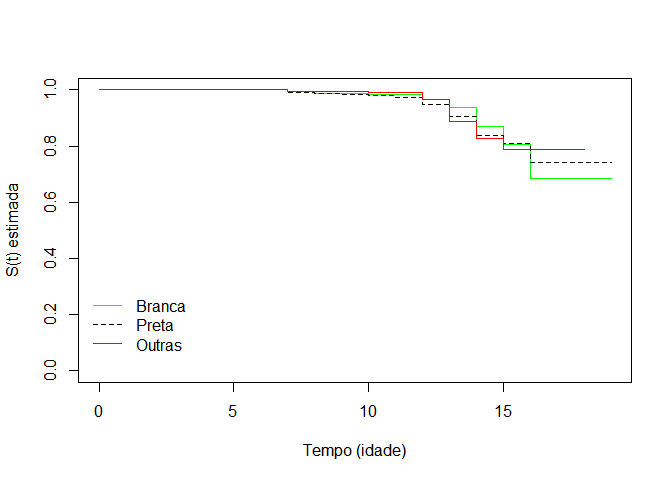

```r
ekm.raca = svykm(Surv(tempo,censura)~raca,design=desenhoRJ, )
plot(ekm.raca, ylab = "S(t) estimada",xlab = "Tempo (idade)"
     ,pars=list(lty=c(1,2,1,2),col=c("green","black","red", "transparent")))
Legenda<-c("Branca", "Preta", "Outras ",  "")
legend("bottomleft", Legenda,lwd=c(1,1),cex=1,inset=0.00,col=c("green","black","red", "transparent"),bty="n", lty = c(1,2,1,2))
```

### Construção da função do tempo médio da iniciação da experimentação do fenômeno. Vale ressaltar que como boa parte dos dados são censurados, esse tempo médio não será muito preciso.

```r
#Função do tempo médio
tempm = function(var){
        aprox = c()
        for (j in 1:length(var$time)-1) {
                stj = var$surv[j]
                tj1 = var$time[j+1]
                tj=   var$time[j]
                aprox[j] = stj*(tj1-tj)
        }
        med = var$time[1] + sum(aprox)
        med
}
```

### Tempo médio da experimentação do fenômeno.

```r
print("Sexo Masculino")
```

```
## [1] "Sexo Masculino"
```

```r
tempm(ekm.sexo$'1')
```

```
## [1] 17.89764
```

```r
print("Sexo Feminino")
```

```
## [1] "Sexo Feminino"
```

```r
tempm(ekm.sexo$'2')
```

```
## [1] 17.34531
```

```r
print("Escola pública")
```

```
## [1] "Escola pública"
```

```r
tempm(ekm.depAdm$"1")
```

```
## [1] 17.59019
```

```r
print("Escola particular")
```

```
## [1] "Escola particular"
```

```r
tempm(ekm.depAdm$"2")
```

```
## [1] 17.64046
```

```r
print("Raça branca")
```

```
## [1] "Raça branca"
```

```r
tempm(ekm.raca$"1")
```

```
## [1] 17.56789
```

```r
print("Raça negra")
```

```
## [1] "Raça negra"
```

```r
tempm(ekm.raca$"2")
```

```
## [1] 17.64447
```

```r
print("Outras Raças")
```

```
## [1] "Outras Raças"
```

```r
tempm(ekm.raca$"3")
```

```
## [1] 17.00562
```